# M05-Application-Data_Wrangling_Tidyverse

Author

Andrew Ingraham

Published

March 7, 2025

# 1

**Create a new project called “M05_02”. Inside this project, create a new Quarto Markdown file called “M05-2-Data_Wrangling_Tidyverse.qmd”**

## 1.1 Now, using the Tidyverse library, set the built-in “airquality” dataset to a tibble format named, “air.tib.” Confirm that the operation was successful. Next, create a new data frame from “air.tib” and assign “air.df” to the data frame. Confirm that the operation was successful.

```r
library(tidyverse)
air.tib <- as_tibble(airquality)
print(air.tib)
```

```
# A tibble: 153 × 6
   Ozone Solar.R  Wind  Temp Month   Day
   <int>   <int> <dbl> <int> <int> <int>
 1    41     190   7.4    67     5     1
 2    36     118   8      72     5     2
 3    12     149  12.6    74     5     3
 4    18     313  11.5    62     5     4
 5    NA      NA  14.3    56     5     5
 6    28      NA  14.9    66     5     6
 7    23     299   8.6    65     5     7
 8    19      99  13.8    59     5     8
 9     8      19  20.1    61     5     9
10    NA     194   8.6    69     5    10
# ℹ 143 more rows
```

```r
air.df <- as.data.frame(air.tib)
print(air.df)
```

```
    Ozone Solar.R Wind Temp Month Day
1      41     190  7.4   67     5   1
2      36     118  8.0   72     5   2
3      12     149 12.6   74     5   3
4      18     313 11.5   62     5   4
5      NA      NA 14.3   56     5   5
6      28      NA 14.9   66     5   6
7      23     299  8.6   65     5   7
8      19      99 13.8   59     5   8
9       8      19 20.1   61     5   9
10     NA     194  8.6   69     5  10
11      7      NA  6.9   74     5  11
12     16     256  9.7   69     5  12
13     11     290  9.2   66     5  13
14     14     274 10.9   68     5  14
```

[output cut: 139 more lines]

## 1.2 Using the tibble you created earlier, find the Ozone amount when the temperature was 97. Show this by both subsetting the entire row and pinpointing the Ozone element only. Also, for both ways, use Base R approach as well as Tidyverse approach.

```r
subset_row_tidy <- air.tib %>% filter(Temp == 97)
print(subset_row_tidy)
```

```
# A tibble: 1 × 6
  Ozone Solar.R  Wind  Temp Month   Day
  <int>   <int> <dbl> <int> <int> <int>
1    76     203   9.7    97     8    28
```

```r
ozone_value_tidy <- air.tib %>% filter(Temp == 97) %>% pull(Ozone)
print(ozone_value_tidy)
```

```
[1] 76
```

```r
subset_row <- air.tib[air.tib$Temp == 97, ]
print(subset_row)
```

```
# A tibble: 1 × 6
  Ozone Solar.R  Wind  Temp Month   Day
  <int>   <int> <dbl> <int> <int> <int>
1    76     203   9.7    97     8    28
```

```r
ozone_value <- air.tib$Ozone[air.tib$Temp == 97]
print(ozone_value)
```

```
[1] 76
```

# 2

**Use “flights” data for this exercise.**

## 2.1 Select only the top 10 worst arrival delays for each day for each month for each year. Using the subset of the data, calculate the average delay for each month regardless of the dates or years.

> **Hints:** you will want to group the data by year, month, and day. Then, you will want to ungroup the data to remove the groupings and do another grouping to calculate means by month.

```r
library(tidyverse)
library(nycflights13)

top_10_delays <- flights %>%
  group_by(year, month, day) %>%
  arrange(desc(arr_delay)) %>%
  slice_max(arr_delay, n = 10, with_ties = FALSE) %>%
  ungroup()

avg_monthly_delays <- top_10_delays %>%
  group_by(month) %>%
  summarize(avg_delay = mean(arr_delay, na.rm = TRUE))

print(avg_monthly_delays)
```

```
# A tibble: 12 × 2
   month avg_delay
   <int>     <dbl>
 1     1      200.
 2     2      199.
 3     3      202.
 4     4      220.
 5     5      202.
 6     6      249.
 7     7      254.
 8     8      195.
 9     9      166.
10    10      161.
11    11      162.
12    12      225.
```

## 2.2 Visualize the data that shows average delays each month. Style the chart appropriately, as you learned in the previous modules, to make the chart presentable.

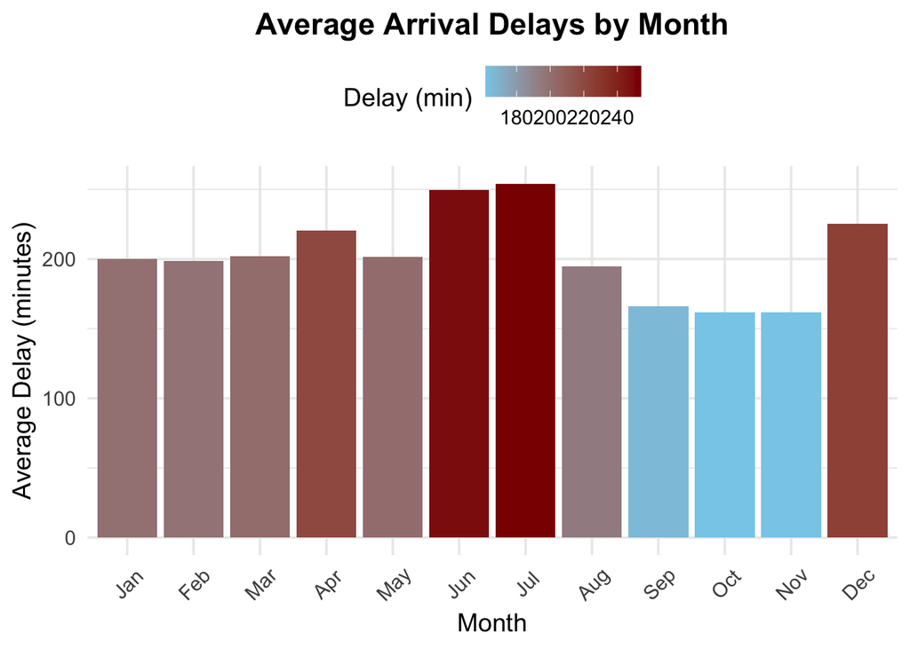

```r
avg_monthly_delays %>%
  ggplot(aes(x = factor(month, labels = month.abb), y = avg_delay, fill = avg_delay)) +
  geom_col() +
  labs(
    title = "Average Arrival Delays by Month",
    x = "Month",
    y = "Average Delay (minutes)"
  ) +
  scale_fill_gradient(low = "skyblue", high = "darkred", name = "Delay (min)") +
  theme_minimal(base_size = 14) +
  theme(
    plot.title = element_text(hjust = 0.5, face = "bold"),
    axis.text.x = element_text(angle = 45, vjust = 0.6),
    legend.position = "top"
  )
```

## 2.3 Describe what you learned from the data about delays. Since this is an important insight, you will want the audience to pay attention and style the description of insights using appropriate Quarto document features.

**The data shows that June and July experience the highest amount of delays. With this graph I could say that June and July are the busiest travel moneth which would lead to the delays. We can also see that September, October, and November have the least amount of delays. This would mean that these months are the least busiest and dont have as many delays.**

# 3

*The final goal of this exercise is to visualize the data. To do so, you will want to understand the data and determine the kind of relationship you would like to visualize. Next you will want to wrangle data to support the visualization objective. In the following sub-questions, you will be asked a step-by-step process. Organize well in your Quarto Markdown by showing sub-question numbers: 3.1, 3.2, 3.3, 3.4, and 3.5 right above each code chunk, except for 3.3. Note that the 3.3 activity doesn’t require coding, but you need to provide your answer as text in the text area, not inside the code chunk. This is because When your response is longer than one line inside the code chunk, the response will go out of the boundary of the chunk highlight when knitted.*

## 3.1 Take a look at the built-in data frame “relig_income” from tidyr package, which is one of the packages included in the mega package called the Tidyverse package. Since you already loaded it up with the package earlier, the data set should show up when you type it. Perform some built-in functions that will help you understand the data – type of data, size, missing value, variables, etc. What can you tell about the data set?

```r
library(tidyverse)

print(relig_income)
```

```
# A tibble: 18 × 11
   religion `<$10k` `$10-20k` `$20-30k` `$30-40k` `$40-50k` `$50-75k` `$75-100k`
   <chr>      <dbl>     <dbl>     <dbl>     <dbl>     <dbl>     <dbl>      <dbl>
 1 Agnostic      27        34        60        81        76       137        122
 2 Atheist       12        27        37        52        35        70         73
 3 Buddhist      27        21        30        34        33        58         62
 4 Catholic     418       617       732       670       638      1116        949
 5 Don’t k…      15        14        15        11        10        35         21
 6 Evangel…     575       869      1064       982       881      1486        949
 7 Hindu          1         9         7         9        11        34         47
 8 Histori…     228       244       236       238       197       223        131
 9 Jehovah…      20        27        24        24        21        30         15
10 Jewish        19        19        25        25        30        95         69
11 Mainlin…     289       495       619       655       651      1107        939
12 Mormon        29        40        48        51        56       112         85
13 Muslim         6         7         9        10         9        23         16
14 Orthodox      13        17        23        32        32        47         38
15 Other C…       9         7        11        13        13        14         18
16 Other F…      20        33        40        46        49        63         46
17 Other W…       5         2         3         4         2         7          3
18 Unaffil…     217       299       374       365       341       528        407
# ℹ 3 more variables: `$100-150k` <dbl>, `>150k` <dbl>,
#   `Don't know/refused` <dbl>
```

```r
str(relig_income)
```

```
tibble [18 × 11] (S3: tbl_df/tbl/data.frame)
 $ religion          : chr [1:18] "Agnostic" "Atheist" "Buddhist" "Catholic" ...
 $ <$10k             : num [1:18] 27 12 27 418 15 575 1 228 20 19 ...
 $ $10-20k           : num [1:18] 34 27 21 617 14 869 9 244 27 19 ...
 $ $20-30k           : num [1:18] 60 37 30 732 15 ...
 $ $30-40k           : num [1:18] 81 52 34 670 11 982 9 238 24 25 ...
 $ $40-50k           : num [1:18] 76 35 33 638 10 881 11 197 21 30 ...
 $ $50-75k           : num [1:18] 137 70 58 1116 35 ...
 $ $75-100k          : num [1:18] 122 73 62 949 21 949 47 131 15 69 ...
 $ $100-150k         : num [1:18] 109 59 39 792 17 723 48 81 11 87 ...
 $ >150k             : num [1:18] 84 74 53 633 18 414 54 78 6 151 ...
 $ Don't know/refused: num [1:18] 96 76 54 1489 116 ...
```

```r
dim(relig_income)
```

```
[1] 18 11
```

```r
sum(is.na(relig_income))
```

```
[1] 0
```

```r
summary(relig_income)
```

```
   religion             <$10k           $10-20k          $20-30k
 Length:18          Min.   :  1.00   Min.   :  2.00   Min.   :   3.0
 Class :character   1st Qu.: 12.25   1st Qu.: 14.75   1st Qu.:  17.0
 Mode  :character   Median : 20.00   Median : 27.00   Median :  33.5
                    Mean   :107.22   Mean   :154.50   Mean   : 186.5
                    3rd Qu.:170.00   3rd Qu.:193.00   3rd Qu.: 192.0
                    Max.   :575.00   Max.   :869.00   Max.   :1064.0
    $30-40k          $40-50k         $50-75k           $75-100k
 Min.   :  4.00   Min.   :  2.0   Min.   :   7.00   Min.   :  3.00
 1st Qu.: 15.75   1st Qu.: 15.0   1st Qu.:  34.25   1st Qu.: 25.25
 Median : 40.00   Median : 34.0   Median :  66.50   Median : 65.50
 Mean   :183.44   Mean   :171.4   Mean   : 288.06   Mean   :221.67
 3rd Qu.:198.75   3rd Qu.:166.8   3rd Qu.: 201.50   3rd Qu.:128.75
 Max.   :982.00   Max.   :881.0   Max.   :1486.00   Max.   :949.00
   $100-150k         >150k        Don't know/refused
 Min.   :  4.0   Min.   :  4.00   Min.   :   8.00
 1st Qu.: 22.5   1st Qu.: 23.75   1st Qu.:  41.25
 Median : 48.5   Median : 53.50   Median :  74.50
 Mean   :177.6   Mean   :144.89   Mean   : 340.06
 3rd Qu.:103.5   3rd Qu.:134.25   3rd Qu.: 294.75
 Max.   :792.0   Max.   :634.00   Max.   :1529.00
```

**This is a data frame. The function relig_income is a data frame that is included with tidyr. Using the sum function we can determine whether the dataset contains any missing values. Using the functions summary and str we can indetify the disruption of values and the overall structure.**

## 3.2 It is a tibble data format with 18 rows and 11 variables. To learn more about this data, look it up in help. Type the code to do so.

> **Hint**: use help() function. What does it tell you about the data and variables? Make sure you type your responses outside below the cord chunk.

```r
help("relig_income", package = "tidyr")
```

## 3.3 Now, go back to the data. Think about the relationships among the variables you want to visualize. One potential idea is to show what the frequency (count) of income brackets look like by the religion people practice. Does the current data allow you to support your goal? Why or why not. If the data doesn’t support the goal, how should the data be reshaped to support the goal?

**Hint**: In your response, consider the conditions for tidy data and if the current data is tidy. Data is tidy when (1) observations in the rows are unique, (2) variables in the columns are consistent and unique so that we can perform statistics that are interpretable.

## 3.4 Reshape the data. Further, draw a plot that shows income distribution by religion. Do all the necessary operations to make the chart visualize the tidied data well.

```r
relig_income_longer <- relig_income %>%
  pivot_longer(
    cols = -religion,
    names_to = "income",
    values_to = "count"
  ) %>%
  filter(income != "Don't know/refused")
print(relig_income_longer)
```

```
# A tibble: 162 × 3
   religion income    count
   <chr>    <chr>     <dbl>
 1 Agnostic <$10k        27
 2 Agnostic $10-20k      34
 3 Agnostic $20-30k      60
 4 Agnostic $30-40k      81
 5 Agnostic $40-50k      76
 6 Agnostic $50-75k     137
 7 Agnostic $75-100k    122
 8 Agnostic $100-150k   109
 9 Agnostic >150k        84
10 Atheist  <$10k        12
# ℹ 152 more rows
```

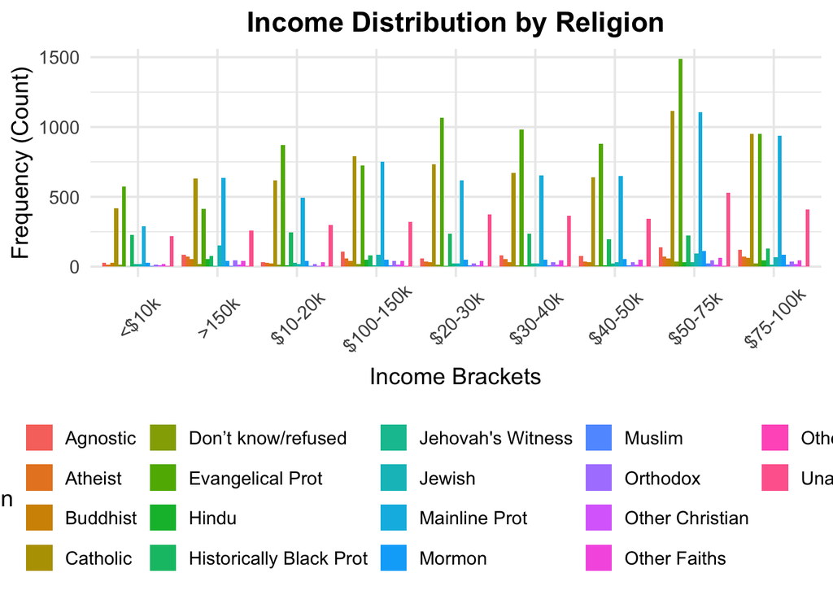

```r
relig_income_longer %>%
  ggplot(aes(x = income, y = count, fill = religion)) +
  geom_bar(stat = "identity", position = "dodge") +
  labs(
    title = "Income Distribution by Religion",
    x = "Income Brackets",
    y = "Frequency (Count)",
    fill = "Religion"
  ) +
  theme_minimal(base_size = 14) +
  theme(
    plot.title = element_text(hjust = 0.5, face = "bold"),
    axis.text.x = element_text(angle = 45, vjust = 0.6),
    legend.position = "bottom"
  )
```

**3.5.** Next, redo 3.4 using one long chain of codes from the first step to the last that spans the whole data wrangling and visualization.

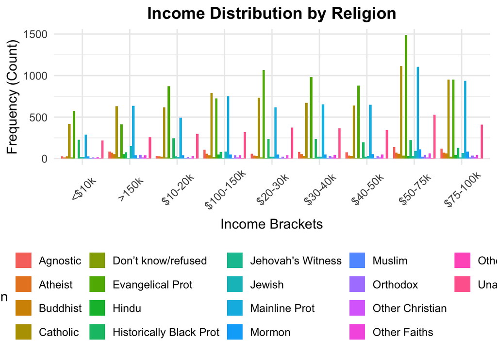

```r
library(tidyverse)
relig_income %>%
  pivot_longer(
    cols = -religion,
    names_to = "income",
    values_to = "count"
  ) %>%
  filter(income != "Don't know/refused") %>%
  ggplot(aes(x = income, y = count, fill = religion)) +
  geom_bar(stat = "identity", position = "dodge") +
  labs(
    title = "Income Distribution by Religion",
    x = "Income Brackets",
    y = "Frequency (Count)",
    fill = "Religion"
  ) +
  theme_minimal(base_size = 14) +
  theme(
    plot.title = element_text(hjust = 0.5, face = "bold"),
    axis.text.x = element_text(angle = 45, vjust = 0.6),
    legend.position = "bottom"
  )
```

# 4

*Just like Question 3, the goal is to visualize the data and do the appropriate wrangling needed to support the goal. First, understand the data and think about what kinds of relationships would be most interesting to show in visualization given the data. If the data is not in ideal shape to support your visualization goal, do all the wrangling needed to support your goal. Organize your codebook well by showing sub-question numbers: 4.1, 4.2, 4.3, 4.4, and 4.5. Note that the 4.3 activity doesn’t require coding, so you should provide your answer in the text area.*

## 4.1 Take a look at the built-in data frame “us_rent_income” from tidyr package, which is one of the packages included in the mega package called Tidyverse package. Since you already loaded it up with the package earlier, the data set should show up when you type it. Perform some built-in functions that will help you understand the data – type of data, size, missing value, variables, etc. What can you tell about the data set?

```r
library(tidyr)
library(dplyr)
str(us_rent_income)
```

```
tibble [104 × 5] (S3: tbl_df/tbl/data.frame)
 $ GEOID   : chr [1:104] "01" "01" "02" "02" ...
 $ NAME    : chr [1:104] "Alabama" "Alabama" "Alaska" "Alaska" ...
 $ variable: chr [1:104] "income" "rent" "income" "rent" ...
 $ estimate: num [1:104] 24476 747 32940 1200 27517 ...
 $ moe     : num [1:104] 136 3 508 13 148 4 165 5 109 3 ...
```

```r
dim(us_rent_income)
```

```
[1] 104   5
```

```r
sum(is.na(us_rent_income))
```

```
[1] 2
```

```r
summary(us_rent_income)
```

```
    GEOID               NAME             variable            estimate
 Length:104         Length:104         Length:104         Min.   :  464.0
 Class :character   Class :character   Class :character   1st Qu.:  864.5
 Mode  :character   Mode  :character   Mode  :character   Median : 1507.0
                                                          Mean   :14923.1
                                                          3rd Qu.:28872.0
                                                          Max.   :43198.0
                                                          NA's   :1
      moe
 Min.   :  2.0
 1st Qu.:  4.5
 Median : 18.0
 Mean   : 95.5
 3rd Qu.:153.5
 Max.   :681.0
 NA's   :1
```

```r
head(us_rent_income)
```

```
# A tibble: 6 × 5
  GEOID NAME    variable estimate   moe
  <chr> <chr>   <chr>       <dbl> <dbl>
1 01    Alabama income      24476   136
2 01    Alabama rent          747     3
3 02    Alaska  income      32940   508
4 02    Alaska  rent         1200    13
5 04    Arizona income      27517   148
6 04    Arizona rent          972     4
```

## 4.2 You will see five variables: GEOID, NAME, variable, estimate, and moe. To understand the data, type a code that will show you the description of the data in the help. Then read the description of the variables. What does it tell you about the data and variables? What does each variable mean? Make sure you type your responses outside below the cord chunk.

```r
help("us_rent_income", package = "tidyr")
```

**It tells me that the variable is the income of the median yearly income and the rent is median monhtly rent. These are catagorical variables.**

## 4.3 Now, go back to the data. Think about the relationships among the variables you want to visualize. One potential idea is to show the relationship between income and rent across the states. Ask yourself if the current data shape supports your visualization goal. Why or why not? If the data doesn’t support the goal, how should the data be reshaped to support the goal?

> **Hints**: In your response, consider the conditions for tidy data and if the current data is tidy. Data is tidy when (1) observations in the rows are unique, (2) variables in the columns are consistent and unique so that we can perform statistics that are interpretable.

**I do not believe that that the dataset fully supports the goal. I could reshape the dataset by fixing the estimate column. Another way to reshape this dataset would be to fix the variable column. I should seperate the columns, one should be “income” and “rent.”**

## 4.4 Reshape the data. Further, draw a plot that shows the relationship between the income and rent across the states. Do all the necessary operations to make the chart visualize the tidied data well.

> **Hint**: The successful data will have six columns: “GEOID”, “NAME”, “estimate_income”, “estimate_rent”, “moe_income”, and “moe_rent.” Assign “us_rent_income_wider” to the tydy data and print it out. whereas “names_from” argument has one variable – “variable”, “values_from” argument has two variables – “estimate” and “moe.” Multiple variables can be combined with c() function like this: c(estimate, moe).

```r
library(tidyr)
library(dplyr)
library(ggplot2)
us_rent_income_wider <- us_rent_income %>%
  pivot_wider(
    names_from = variable,
    values_from = c(estimate, moe)
  )
colnames(us_rent_income_wider) <- c("GEOID", "NAME", "estimate_income", "estimate_rent", "moe_income", "moe_rent")
print(us_rent_income_wider)
```

```
# A tibble: 52 × 6
   GEOID NAME                 estimate_income estimate_rent moe_income moe_rent
   <chr> <chr>                          <dbl>         <dbl>      <dbl>    <dbl>
 1 01    Alabama                        24476           747        136        3
 2 02    Alaska                         32940          1200        508       13
 3 04    Arizona                        27517           972        148        4
 4 05    Arkansas                       23789           709        165        5
 5 06    California                     29454          1358        109        3
 6 08    Colorado                       32401          1125        109        5
 7 09    Connecticut                    35326          1123        195        5
 8 10    Delaware                       31560          1076        247       10
 9 11    District of Columbia           43198          1424        681       17
10 12    Florida                        25952          1077         70        3
# ℹ 42 more rows
```

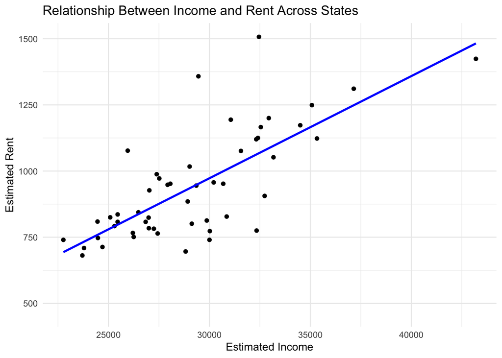

```r
ggplot(data = us_rent_income_wider, aes(x = estimate_income, y = estimate_rent)) +
  geom_point() +
  geom_smooth(method = "lm", se = FALSE, color = "blue") +
  labs(
    title = "Relationship Between Income and Rent Across States",
    x = "Estimated Income",
    y = "Estimated Rent"
  ) +
  theme_minimal()
```

## 4.5 This time, repeat what you did earlier in 4.4., from tidying the data to visualizing the data, in one chain of codes using the Tidyverse way.

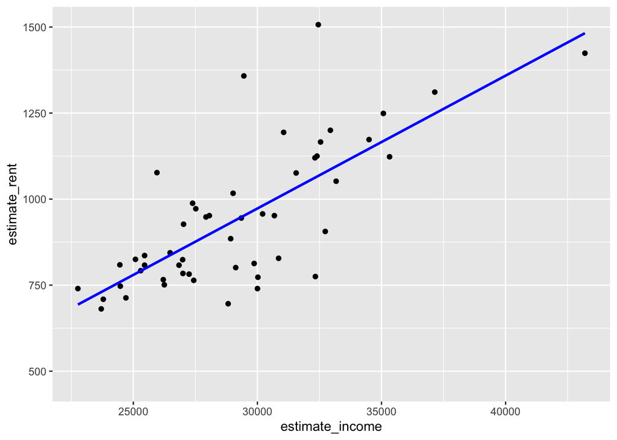

```r
library(tidyverse)
us_rent_income %>%
  pivot_wider(
    names_from = variable,
    values_from = c(estimate, moe)
  ) %>%
  rename(
    estimate_income = estimate_income,
    estimate_rent = estimate_rent,
    moe_income = moe_income,
    moe_rent = moe_rent
  ) %>%
  ggplot(aes(x = estimate_income, y = estimate_rent)) +
  geom_point() +
  geom_smooth(method = "lm", se = FALSE, color = "blue")
```

# 5

**Run this code below:**

> mba <- data.frame(player=c(‘A’, ‘A’, ‘B’, ‘B’, ‘C’, ‘C’),  
> year=c(1, 2, 1, 2, 1, 2),  
> stats=c(‘22/2/3’, ‘29/3/4’, ‘18/6/7’, ‘11/1/2’, ‘12/1/1’, ‘19/2/4’))

```r
library(tidyr)
mba <- data.frame(player=c('A', 'A', 'B', 'B', 'C', 'C'),
                  year=c(1, 2, 1, 2, 1, 2),
                  stats=c('22/2/3', '29/3/4', '18/6/7', '11/1/2', '12/1/1', '19/2/4'))
```

## 5.1 Next, separate the number of the stats column into “points,” “assists,” and “steals.” Assign this data frame to a new name, “mba_sep”. Print out the data set.

```r
mba_sep <- mba %>%
  separate(stats, into = c("points", "assists", "steals"), sep = "/")
print(mba_sep)
```

```
  player year points assists steals
1      A    1     22       2      3
2      A    2     29       3      4
3      B    1     18       6      7
4      B    2     11       1      2
5      C    1     12       1      1
6      C    2     19       2      4
```

## 5.2 Reverse the last question by uniting three columns – points, assists and steals – into one column. Assign “mba_uni” to the data frame. Then confirm the work by printing it out on the screen.

```r
mba_uni <- mba_sep %>%
  unite("stats", points:steals, sep = "/")
print(mba_uni)
```

```
  player year  stats
1      A    1 22/2/3
2      A    2 29/3/4
3      B    1 18/6/7
4      B    2 11/1/2
5      C    1 12/1/1
6      C    2 19/2/4
```

# 6

Use the “flights” data.

## 6.1 Filter the data by including only the flights that were not canceled. For each day, calculate the first and last departure times from NYC airport. Then, for each month, select one day such that the first flight departure was the latest for the month. Do the necessary wrangling and show the results in descending order of “first departure time” in a table using the `*gt*`/`*gtExtras*.`

> **Hint**: You can use group_by() and summarize(), filter(), ungroup(), and arrange() functions. In the end, you should have 12 rows of data frame consisting of columns such as year, month, day, first_dep, last_dep, and n.

```r
library(nycflights13)
library(dplyr)
library(gt)
daily_departures <- flights %>%
  filter(!is.na(dep_time)) %>%
  group_by(year, month, day) %>%
  summarize(
    first_dep = min(dep_time, na.rm = TRUE),
    last_dep = max(dep_time, na.rm = TRUE),
    n = n()
  ) %>%
  ungroup()
latest_first_departures <- daily_departures %>%
  group_by(year, month) %>%
  filter(first_dep == max(first_dep)) %>%
  ungroup() %>%
  arrange(desc(first_dep))
latest_first_departures %>%
  gt() %>%
  tab_header(
    title = "Days with Latest First Departures",
    subtitle = "NYC Flights Data, Ordered by First Departure Time"
  ) %>%
  cols_label(
    year = "Year",
    month = "Month",
    day = "Day",
    first_dep = "First Departure Time",
    last_dep = "Last Departure Time",
    n = "Number of Flights"
  )
```

Days with Latest First Departures

NYC Flights Data, Ordered by First Departure Time

| Year | Month | Day | First Departure Time | Last Departure Time | Number of Flights |
| --- | --- | --- | --- | --- | --- |
| 2013 | 2 | 9 | 901 | 2358 | 291 |
| 2013 | 1 | 20 | 525 | 2356 | 782 |
| 2013 | 9 | 29 | 521 | 2356 | 911 |
| 2013 | 10 | 6 | 519 | 2346 | 914 |
| 2013 | 11 | 3 | 519 | 2358 | 900 |
| 2013 | 3 | 3 | 509 | 2353 | 910 |
| 2013 | 12 | 18 | 500 | 2358 | 953 |
| 2013 | 5 | 29 | 457 | 2352 | 969 |
| 2013 | 6 | 15 | 456 | 2356 | 795 |
| 2013 | 4 | 30 | 455 | 2351 | 958 |
| 2013 | 8 | 31 | 455 | 2359 | 676 |
| 2013 | 7 | 5 | 38 | 2358 | 819 |

```r
top_destinations <- flights %>%
  group_by(dest) %>%
  summarize(total_flights = n()) %>%
  arrange(desc(total_flights)) %>%
  slice_head(n = 5)
top_destinations %>%
  gt() %>%
  tab_header(
    title = "Top 5 Flight Destinations",
    subtitle = "Based on Total Flights from NYC Airports"
  ) %>%
  cols_label(
    dest = "Destination",
    total_flights = "Total Flights"
  )
```

Top 5 Flight Destinations

Based on Total Flights from NYC Airports

| Destination | Total Flights |
| --- | --- |
| ORD | 17283 |
| ATL | 17215 |
| LAX | 16174 |
| BOS | 15508 |
| MCO | 14082 |

# 7

Using the data frame “air.tib,” find out how many missing values exist in the column “Solar.R and what percent of the record the missing values account for”. In doing so, try Tidyverse way of coding. Next, create a variable called “Solar_Mean” and assign the mean of the column “Solar.R” to it. Finally, replace all the missing values in the column “Solar.R” with “Soar_Mean”. Confirm that there are no more missing values in this column.

```r
library(dplyr)
library(tidyr)
missing_info <- air.tib %>%
  summarise(
    total_records = n(),
    missing_values = sum(is.na(Solar.R)),
    missing_percent = (sum(is.na(Solar.R)) / n()) * 100
  )
print(missing_info)
```

```
# A tibble: 1 × 3
  total_records missing_values missing_percent
          <int>          <int>           <dbl>
1           153              7            4.58
```

```r
Solar_Mean <- air.tib %>%
  summarise(mean_solar = mean(Solar.R, na.rm = TRUE)) %>%
  pull(mean_solar)

print(Solar_Mean)
```

```
[1] 185.9315
```

```r
air.tib <- air.tib %>%
  mutate(Solar.R = if_else(is.na(Solar.R), Solar_Mean, Solar.R))

missing_check <- sum(is.na(air.tib$Solar.R))

print(missing_check)
```

```
[1] 0
```

# 8

Use the air.tib data frame. Here, the goal is to visualize the monthly total temperature (silly?) with a barplot with the Month on the y-axis and the total temperature on the x-axis. To do so, do the appropriate wrangling and visualization in one chain of codes. To do so, do the following.

- - - - 1. To create the total monthly temperature, count the number of months weighted by Temp.
      - 2. Change Month’s data from numeric value to associated character: from 5 to “May”, 6 to “June”, 7 to “July”, 8 to “August”, and 9 to “September”.
      - 3. Convert Month to a factor.
      - 4. Reorder Month by the size of the total temperature in descending order.

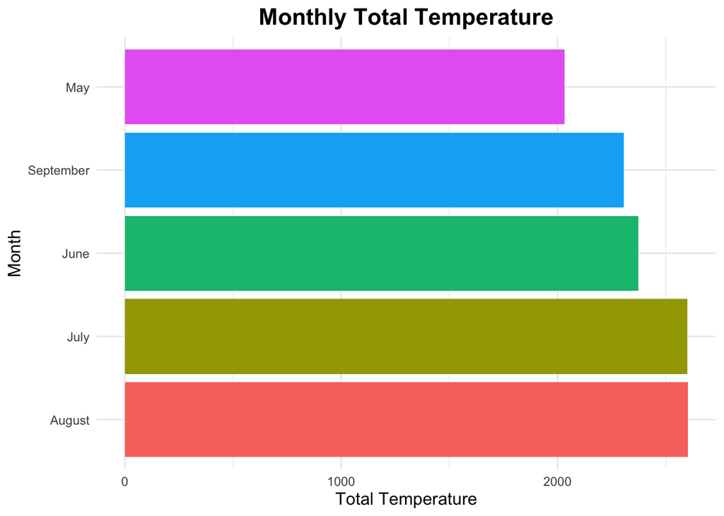

```r
library(dplyr)
library(ggplot2)
air.tib %>%
  group_by(Month) %>%
  summarise(total_temp = sum(Temp, na.rm = TRUE)) %>%
  mutate(
    Month = recode(Month,
                   `5` = "May",
                   `6` = "June",
                   `7` = "July",
                   `8` = "August",
                   `9` = "September"),
    Month = factor(Month, levels = Month[order(-total_temp)])
  ) %>%
  ggplot(aes(x = total_temp, y = Month, fill = Month)) +
  geom_bar(stat = "identity", show.legend = FALSE) +
  labs(
    title = "Monthly Total Temperature",
    x = "Total Temperature",
    y = "Month"
  ) +
  theme_minimal() +
  theme(
    plot.title = element_text(hjust = 0.5, size = 16, face = "bold"),
    axis.title.x = element_text(size = 12),
    axis.title.y = element_text(size = 12)
  )
```

After you transformed the data s above in two columns – Month and n, you can visualize the table in a barplot. As usual, do the necessary beautification of the chart to make it presentable to the audience. There are at least two ways to wrangle to get the same outcome. If you can do both, you will get a bonus point.

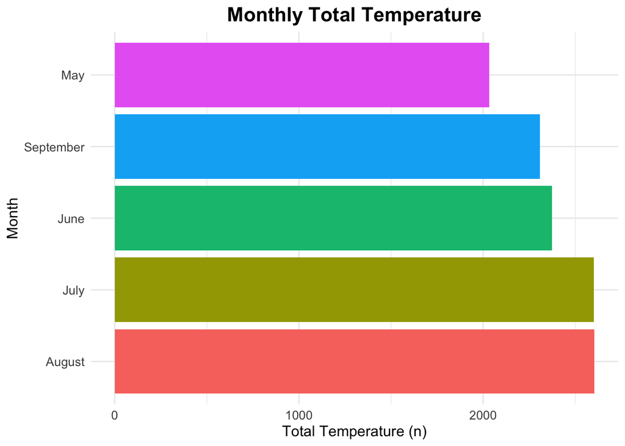

```r
library(dplyr)
library(ggplot2)
air.tib %>%
  group_by(Month) %>%
  summarise(n = sum(Temp, na.rm = TRUE)) %>%
  mutate(
    Month = recode(Month,
                   `5` = "May",
                   `6` = "June",
                   `7` = "July",
                   `8` = "August",
                   `9` = "September"),
    Month = factor(Month, levels = Month[order(-n)])
  ) %>%
  ggplot(aes(x = n, y = Month, fill = Month)) +
  geom_bar(stat = "identity", show.legend = FALSE) +
  labs(
    title = "Monthly Total Temperature",
    x = "Total Temperature (n)",
    y = "Month"
  ) +
  theme_minimal() +
  theme(
    plot.title = element_text(hjust = 0.5, size = 16, face = "bold"),
    axis.title.x = element_text(size = 12),
    axis.title.y = element_text(size = 12),
    axis.text.y = element_text(size = 10),
    axis.text.x = element_text(size = 10)
  )
```

# 9

**Using the air.tib data frame, group the data set by Month. Next, find out the maximum temperature for each month and display the result. Then, pipe the wrangled data into ggplot() and draw an appropriate chart.**

> **Hint**. There is more than one way to do this. You may use a combination of the pipe operator, group_by(), summarize(), and max(). Also, order the month by descending order of the maximum temperature of the month. Do all things to make the visualization most effective.

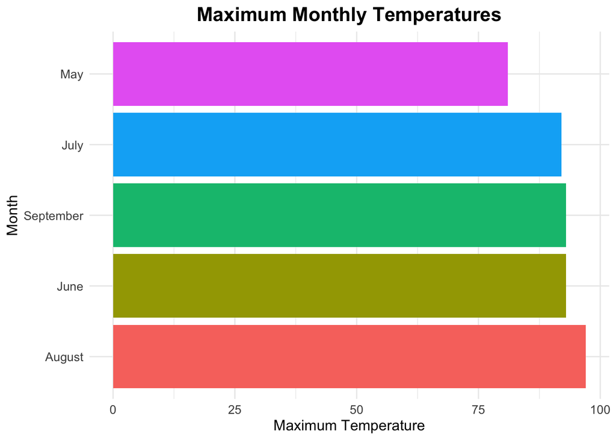

```r
library(dplyr)
library(ggplot2)
air.tib %>%
  group_by(Month) %>%
  summarize(max_temp = max(Temp, na.rm = TRUE)) %>%
  mutate(
    Month = recode(Month,
                   `5` = "May",
                   `6` = "June",
                   `7` = "July",
                   `8` = "August",
                   `9` = "September"),
    Month = factor(Month, levels = Month[order(-max_temp)])
  ) %>%
  ggplot(aes(x = max_temp, y = Month, fill = Month)) +
  geom_bar(stat = "identity", show.legend = FALSE) +
  labs(
    title = "Maximum Monthly Temperatures",
    x = "Maximum Temperature",
    y = "Month"
  ) +
  theme_minimal() +
  theme(
    plot.title = element_text(hjust = 0.5, size = 16, face = "bold"),
    axis.title.x = element_text(size = 12),
    axis.title.y = element_text(size = 12),
    axis.text.y = element_text(size = 10),
    axis.text.x = element_text(size = 10)
  )
```

# 10

**Using the pipe operator on the tibble, “air.tib”, create a new column called “temp_wind”, which is the division of the “Temp” by the “Wind” column. Further, investigate the relationship between Ozone amount and “temp_wind” by visualizing the two variables in a chart. Visualize also the associations between Wind and Ozone as well as Wind and Temp. Visualize all three sets of relationships in a single chart. What can you infer about the relationships among the variables? write a chain of code from the beginning to the end of both wrangling and visualization.**

> **Hint**: It might be helpful to draw the three visualization separately and then think about how to show them in one chart. To do so, you will need to reshape the data so that you can utilize faceting in ggplot2. In any case, you will see the association between Ozone and “temp_wind” will be stronger than the association between Ozone and the temperature or wind separately before Temp and Wind are combined. Investigate the separate relationships and you will understand why the new variable has a stronger impact on Ozone.

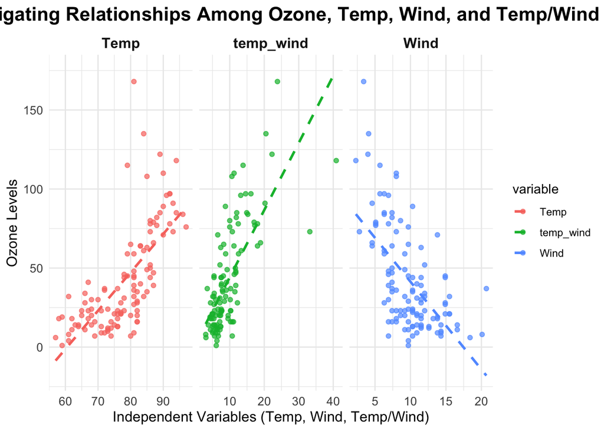

```r
library(dplyr)
library(ggplot2)
library(tidyr)
air.tib %>%
  mutate(temp_wind = Temp / Wind) %>%
  pivot_longer(
    cols = c(temp_wind, Temp, Wind),
    names_to = "variable",
    values_to = "value"
  ) %>%
  filter(!is.na(Ozone)) %>%
  ggplot(aes(x = value, y = Ozone, color = variable)) +
  geom_point(alpha = 0.7) +
  geom_smooth(method = "lm", se = FALSE, linetype = "dashed") +
  facet_wrap(~variable, scales = "free_x") +
  labs(
    title = "Investigating Relationships Among Ozone, Temp, Wind, and Temp/Wind",
    x = "Independent Variables (Temp, Wind, Temp/Wind)",
    y = "Ozone Levels"
  ) +
  theme_minimal() +
  theme(
    plot.title = element_text(hjust = 0.5, size = 16, face = "bold"),
    strip.text = element_text(size = 12, face = "bold"),
    axis.title = element_text(size = 12),
    axis.text = element_text(size = 10)
  )
```